# AEDD: Trabajo Estadística Espacial

Grupo 8

Curso 2023/2024

Este trabajo debe entregarse en formato pdf, incluyendo el código R utilizado, las correspondientes salidas y los comentarios (o interpretaciones de los resultados) pertinentes (para ello se recomienda emplear RMarkdown, a partir de un fichero *.Rmd* o un fichero *.R* mediante spin, que también debe entregarse).

Se empleará el conjunto de datos `temp_andalu` almacenado en el archivo *temp_andalu_X.RData*, donde *X* es el número de grupo, que contiene temperaturas medias (`temp`) mensuales (correspondientes al mes `attr(temp_andalu, "fecha")`, seleccionado al azar de los últimos dos años) en las estaciones de la Red de Información Agroclimática de Andalucía. Las posiciones de las estaciones (`lon`, `lat`) están en coordenadas proyectadas UTM en kilómetros. El objetivo de este trabajo es realizar un análisis geoestadístico de estos datos, utilizando las herramientas explicadas durante las clases.

```r
library(sf)
setwd("C:/Users/marti/Desktop/UNI/AEDD/TrabajoXeo/AEDD") # Poned vuestra ruta
load("./datos_trabajo/temp_andalu_8.RData")
```

La fecha límite de entrega de este trabajo es el **29 de diciembre de 2023** (para poder disponer de la corrección antes del periodo de exámenes). En la evaluación, se tendrá en cuenta la correcta resolución de los ejercicios, la claridad y corrección en la redacción del trabajo, la interpretación y discusión de los resultados y el correcto funcionamiento de los scripts entregados. En caso de que se considere oportuno, se podrá solicitar a los alumnos la presentación oral del trabajo.

# Ejercicios

#### **1. Lectura de datos y análisis exploratorio**

*a) Realizar un breve análisis descriptivo del conjunto de datos y generar un histograma de la respuesta.*

```r
head(temp_andalu)
```

```
##                            lon      lat   temp
## Adamuz                373.1009 4206.523  7.351
## Adra                  500.6943 4066.770 12.270
## Alcaudete             404.7828 4159.455  8.813
## Almería               553.3027 4076.766 12.245
## Almonte               191.2336 4116.957 10.327
## Almonte bajo plástico 183.3459 4109.139 10.351
```

```r
str(temp_andalu)
```

```
## 'data.frame':    101 obs. of  3 variables:
##  $ lon : num  373 501 405 553 191 ...
##  $ lat : num  4207 4067 4159 4077 4117 ...
##  $ temp: num  7.35 12.27 8.81 12.24 10.33 ...
##  - attr(*, "fecha")= chr "1/2022"
```

```r
summary(temp_andalu)
```

```
##       lon             lat            temp
##  Min.   :123.9   Min.   :4019   Min.   : 3.651
##  1st Qu.:230.7   1st Qu.:4100   1st Qu.: 7.462
##  Median :350.1   Median :4137   Median : 9.407
##  Mean   :350.1   Mean   :4135   Mean   : 9.110
##  3rd Qu.:451.2   3rd Qu.:4174   3rd Qu.:10.952
##  Max.   :608.9   Max.   :4263   Max.   :12.337
```

```r
attr(temp_andalu, "fecha") # Mes de las observaciones
```

```
## [1] "1/2022"
```

Las temperaturas se tomaron en enero de 2022.  
Asignamos a una variable a la temperatura de la que vamos a realizar un análisis descriptivo unidimensional.

```r
t <- temp_andalu$temp
summary(t)
```

```
##    Min. 1st Qu.  Median    Mean 3rd Qu.    Max.
##   3.651   7.462   9.407   9.110  10.952  12.337
```

Histograma de la respuesta:

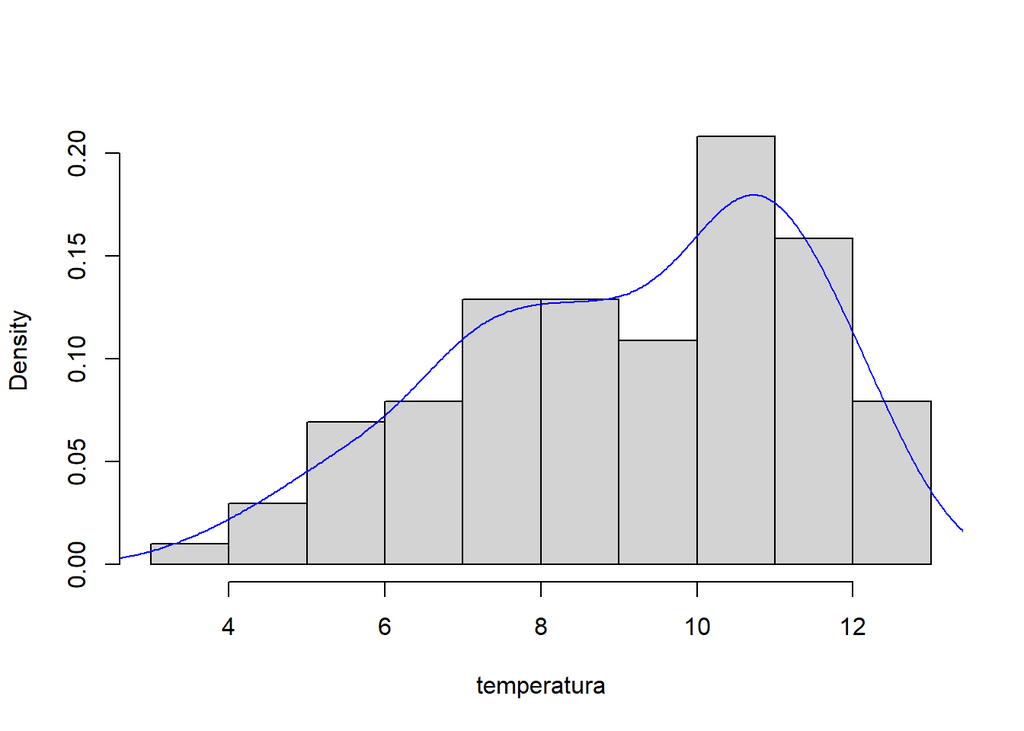

```r
hist(t, xlab = "temperatura", main = "", freq = FALSE)
lines(density(t), col = 'blue')
```

La distribución no es una normal, hay una ligera asimetría.

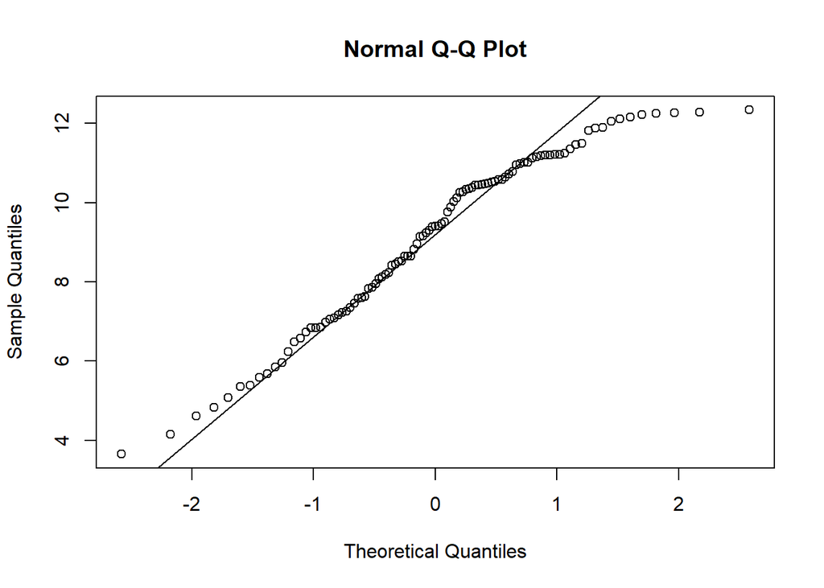

```r
qqnorm(t)
qqline(t)
```

Test de normalidad de Shapiro-Wilk:

```r
shapiro.test(t)
```

```
##
##  Shapiro-Wilk normality test
##
## data:  t
## W = 0.95507, p-value = 0.001706
```

Según el test no hay normalidad.

*b) Convertir el `data.frame` a un objeto `sf`, definiendo el CRS mediante la cadena de texto `"+proj=utm +zone=30 +ellps=WGS84 +units=km"`, y representar la distribución espacial de la respuesta. ¿Se observa algún patrón (más o menos claro)?*

Vamos a convertir los datos a un objeto sf. Mantenemos lan y lot como posibles variables expicativas.

```r
crs <- "+proj=utm +zone=30 +ellps=WGS84 +units=km" # Definimos el CRS

temp_andalu_sf <- st_as_sf(temp_andalu, coords = c("lon", "lat"), remove = FALSE, agr = "constant", crs = crs)
```

Representación de la distribución espacial de la respuesta, asignando un color dependiendo de la temperatura medida en cada observación.

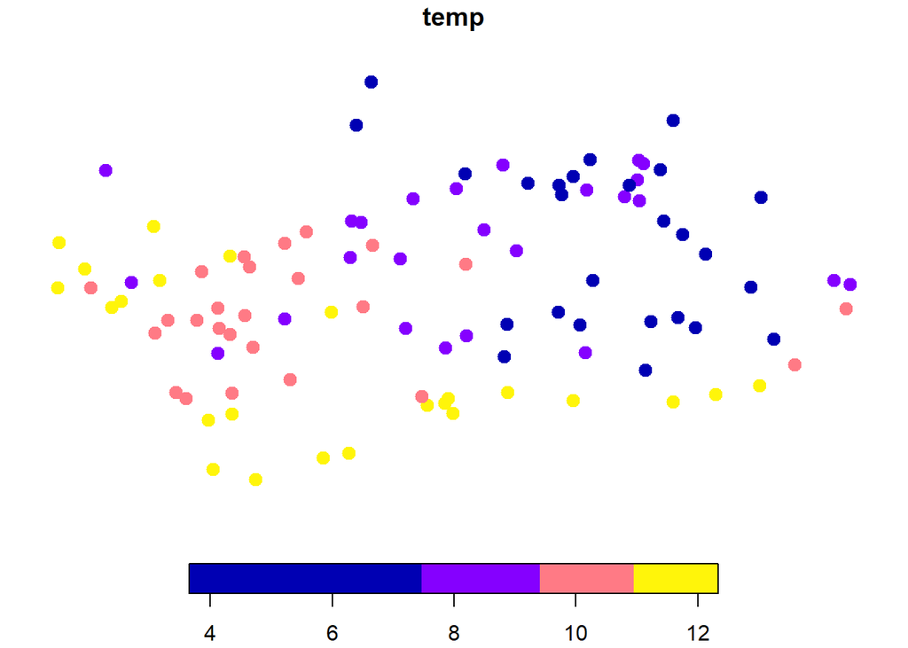

```r
plot(temp_andalu_sf["temp"], pch = 20, cex = 2, breaks = "quantile", nbreaks = 4)
```

Se observa en general temperatura mayor en en los puntos del sur y suroeste y una menor en los puntos del norte y noreste. Estos patrones nos hacen pensar que la tendencia no es constante.

*c) Completar el análisis descriptivo de la variabilidad de gran escala. ¿Aparentemente hay tendencia espacial? En caso afirmativo, sugerir un modelo lineal.*

Completamos el analisis descriptivo de la variabilidad de gran escala con unos gráficos de dispersión de la respuesta frente a coordenadas.

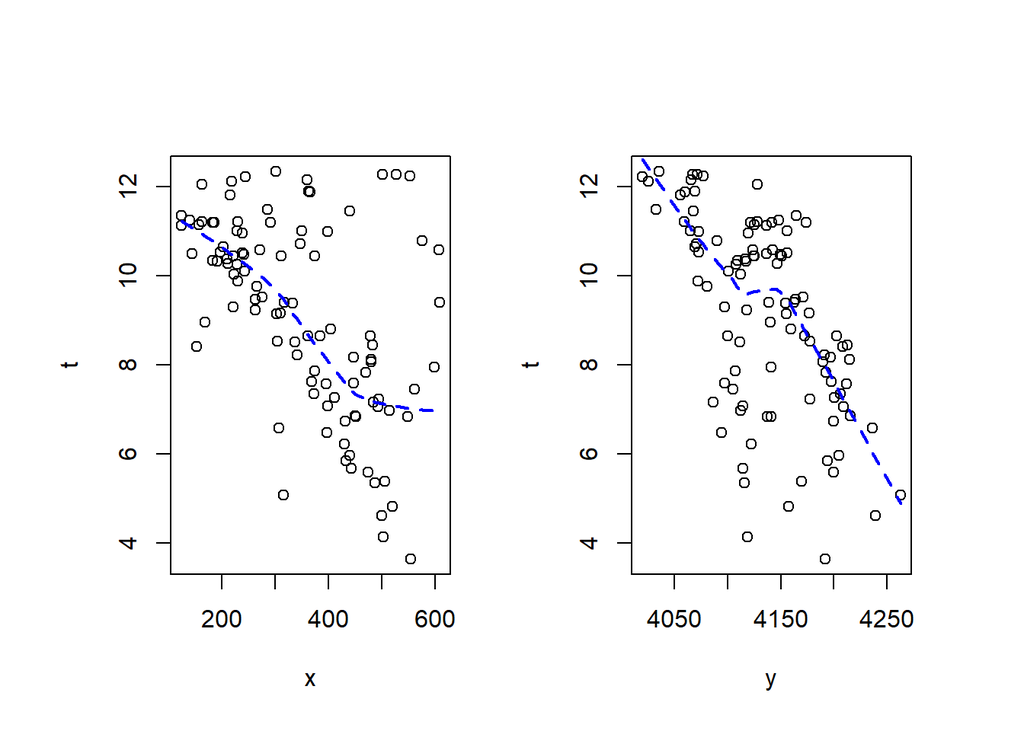

```r
x <- temp_andalu_sf$lon
y <- temp_andalu_sf$lat
old.par <- par(mfrow = c(1, 2), omd = c(0.05, 0.95, 0.01, 0.95))
plot(x, t) # lon frente a temperatura
lines(lowess(x, t), lty = 2, lwd = 2, col = 'blue')
plot(y, t) # lat frente a temperatura
lines(lowess(y, t), lty = 2, lwd = 2, col = 'blue')
```

```r
par(mfrow = c(1,1))
```

Se observa como las dos componentes espaciales, tanto como la longitud como la latitud tienen un efecto en la respuesta por lo que es lógico pensar que existe dependencia espacial. Una tendencia lineal parece adecuada, sugerimos un modelo lineal temp ~ lon + lat Ajustamos el modelo por ols

```r
temp.ols <- lm(temp ~ lon + lat, data = temp_andalu_sf)
summary(temp.ols)
```

```
##
## Call:
## lm(formula = temp ~ lon + lat, data = temp_andalu_sf)
##
## Residuals:
##     Min      1Q  Median      3Q     Max
## -4.1786 -0.9915  0.1171  0.8729  3.3868
##
## Coefficients:
##               Estimate Std. Error t value Pr(>|t|)
## (Intercept) 100.427928  11.657056   8.615 1.21e-13 ***
## lon          -0.007406   0.001152  -6.431 4.65e-09 ***
## lat          -0.021456   0.002835  -7.569 2.08e-11 ***
## ---
## Signif. codes:  0 '***' 0.001 '**' 0.01 '*' 0.05 '.' 0.1 ' ' 1
##
## Residual standard error: 1.472 on 98 degrees of freedom
## Multiple R-squared:  0.5505, Adjusted R-squared:  0.5413
## F-statistic: 60.01 on 2 and 98 DF,  p-value: < 2.2e-16
```

Analizamos los residuos

```r
res <- residuals(temp.ols)
summary(res)
```

```
##    Min. 1st Qu.  Median    Mean 3rd Qu.    Max.
## -4.1786 -0.9915  0.1171  0.0000  0.8729  3.3868
```

Hacemos un histograma de los residuos

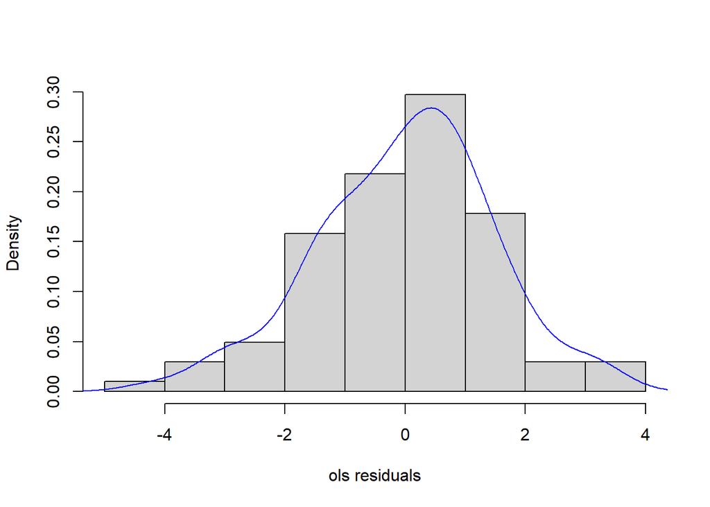

```r
hist(res, xlab = "ols residuals", main = "", freq = FALSE)
lines(density(res), col = 'blue')
```

Los residuos se asemejan bastante a una distribución normal

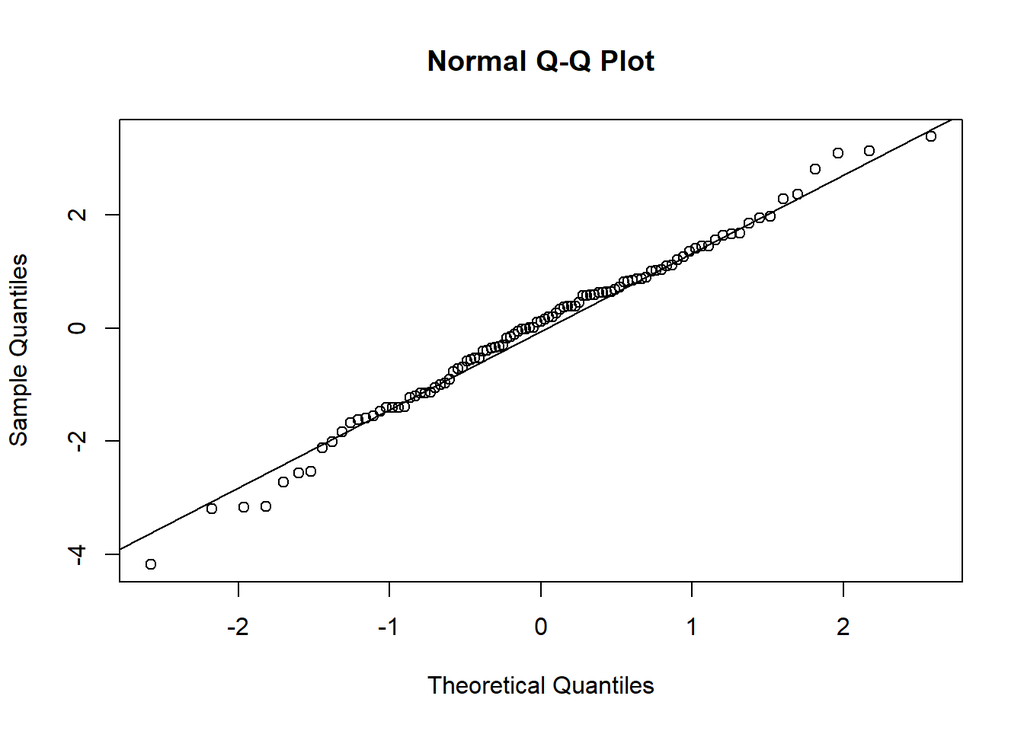

```r
qqnorm(res)
qqline(res)
```

Test de normalidad de Shapiro-Wilk

```r
shapiro.test(res)
```

```
##
##  Shapiro-Wilk normality test
##
## data:  res
## W = 0.99014, p-value = 0.6691
```

Hay normalidad en los residuos

*d) Volver a representar la distribución espacial de la respuesta (o solo las posiciones de observación si surgen dificultades) junto con los límites administrativos de Andalucía (que se pueden obtener empleando el paquete `mapSpain`).*

```r
library(mapSpain)
library(ggplot2)
andalucia_limites <- mapSpain::esp_get_ccaa(ccaa="andalucia")
andalucia_limites <- st_transform(andalucia_limites, crs = crs)
```

Creamos los cuantiles para la distribuir los colores

```r
quantiles <- quantile(temp_andalu_sf$temp, probs = c(0, 0.25, 0.5, 0.75, 1))
```

Hacemos el grafico usando ggplot juntando los límites de Andalucía junto a la representación de la distribución espacial de la respuesta

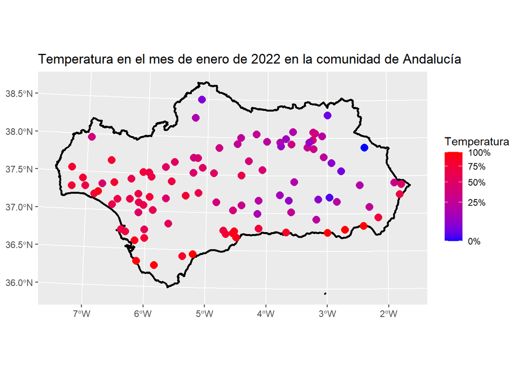

```r
ggplot() +
  geom_sf(data = andalucia_limites, fill = "transparent", color = "black", lwd = 1) +
  geom_sf(data = temp_andalu_sf, aes(color = temp_andalu_sf$temp), pch = 20, cex = 5) +
  scale_color_gradient(breaks = quantiles, low = "blue", high = "red", name = "Temperatura") +
  ggtitle("Temperatura en el mes de enero de 2022 en la comunidad de Andalucía")
```

#### **2. Modelado de la dependencia espacial**

*a) Analiza la variabilidad de pequeña escala empleando el estimador clásico del semivariograma, considerando 20 saltos hasta un salto máximo de 290.*

```r
library(gstat)
maxlag <- 290 # Salto máximo de 290
# Estimador clásico del semivariograma-> cressie = False
vario <- variogram(temp ~ lon + lat, temp_andalu_sf, cutoff = maxlag, width = maxlag/20)
```

Represantación de las estimaciones junto con el número de aportaciones:

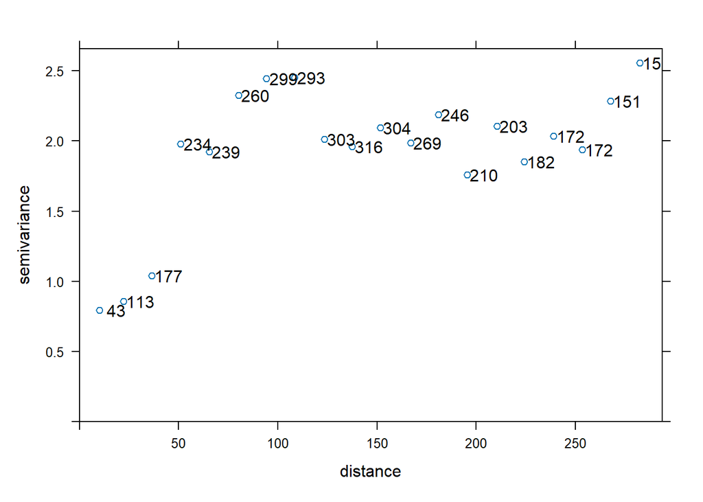

```r
plot(vario, plot.numbers = TRUE)
```

Observamos que las tres primeras estimaciones tienen una semivarianza baja comparada con el resto. A partir de la tercera estimación hay un salto de semivarianza.

*b. Ajustar a las estimaciones piloto un modelo (isotrópico) de semivariograma exponencial y uno esférico, mediante WLS. ¿Con cuál se obtiene un mejor ajuste? Interpretar las estimaciones obtenidas de los parámetros del semivariograma.*

Primero definimos el modelo exponencial con *vgm()*:

```r
modelo_exp <- vgm(model = "Exp", nugget = NA) # Valores iniciales por defecto
```

Ajustamos el modelo con *fit.variogram()* empleando pesos inversamente proporcionales a la varianza (*fit.method = 2*)

```r
fit_exp <- fit.variogram(vario, modelo_exp, fit.method = 2)
fit_exp
```

```
##   model    psill    range
## 1   Nug 0.000000  0.00000
## 2   Exp 2.198348 33.50278
```

Asignamos a variables para trabajar con ellas posteriormente

```r
nugget_exp <- fit_exp$psill[1]
sill_exp <- nugget_exp + fit_exp$psill[2]
```

En el caso de un variograma exponencial, el parámetro que aparece como range es un parámetro de escala proporcional al verdadero rango práctico (tres veces ese valor). Asi que multiplicamos por 3:

```r
range_exp <- 3*fit_exp$range[2]
```

Parámetros del semivariograma:

```r
params_exp <- matrix(c("nugget_exp", "sill_exp", "range_exp", nugget_exp, sill_exp, range_exp), 2, 3, byrow = TRUE)
params_exp
```

```
##      [,1]         [,2]               [,3]
## [1,] "nugget_exp" "sill_exp"         "range_exp"
## [2,] "0"          "2.19834817556355" "100.508331986794"
```

El nugget tiene valor 0 lo cual indica que no hay variabilidad espacial a distancias muy cortas, esto puede significar que no hay irregularidades locales o fluctuaciones a escalas pequeñas. Existe por lo tanto una fuerte dependencia en distancias cortas. El sill es de 2.19, lo cual nos indica el punto en el cual se llega a la variabilidad máxima. El rango es de 100.50 el cual nos indica la distancia donde el variograma alcanza el sill o se estabiliza.

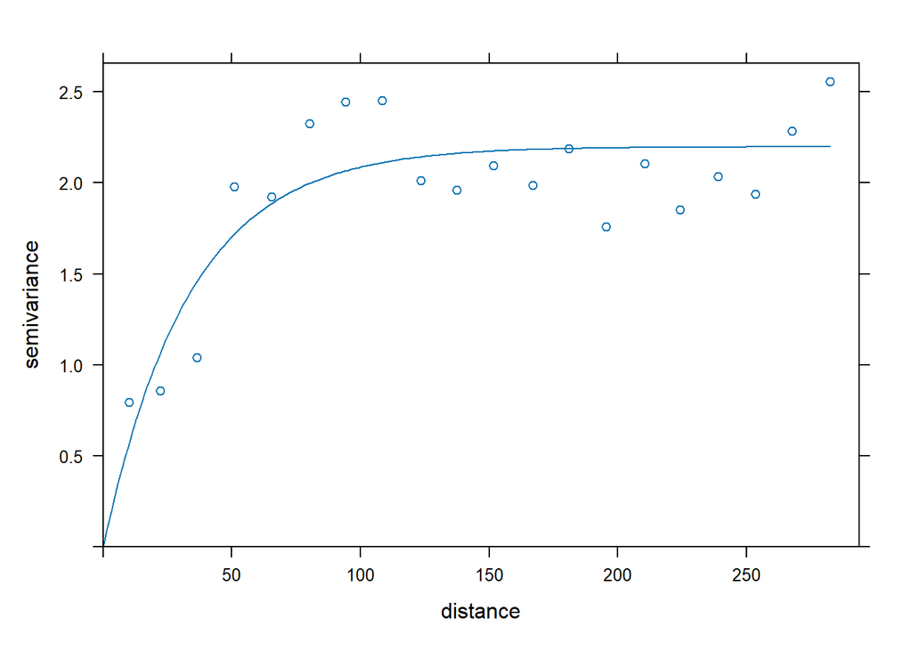

```r
plot(vario, fit_exp)
```

Pintamos los parametros del variograma:

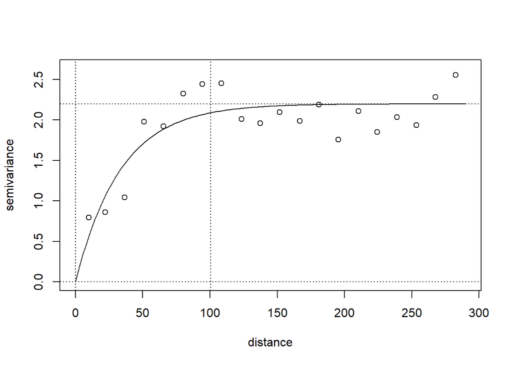

```r
plot(vario$dist, vario$gamma, xlab = "distance", ylab = "semivariance",
     xlim = c(0, max(range_exp*1.1, maxlag)), ylim = c(0, sill_exp*1.2))
lines(variogramLine(fit_exp, maxdist = max(range_exp*1.1, maxlag)))
abline(v = 0, lty = 3)
abline(v = range_exp, lty = 3)
abline(h = nugget_exp, lty = 3)
abline(h = sill_exp, lty = 3)
```

Ahora definimos el modelo esférico:

```r
modelo_sph <- vgm(model = "Sph", nugget = NA) # Valores iniciales por defecto
```

Ajustamos el modelo con *fit.variogram()* empleando pesos inversamente proporcionales a la varianza (*fit.method = 2*)

```r
fit_sph <- fit.variogram(vario, modelo_sph, fit.method = 2)
fit_sph
```

```
##   model     psill    range
## 1   Nug 0.2443188  0.00000
## 2   Sph 1.8910218 87.88994
```

Asignamos a variables para trabajar con ellas posteriormente

```r
nugget_sph <- fit_sph$psill[1]
sill_sph <- nugget_sph + fit_sph$psill[2]
```

En el caso de un variograma esférico el parametro *range* ya es el verdadero rango práctico.

```r
range_sph <- fit_sph$range[2]
```

Parámetros del semivariograma:

```r
params_sph <- matrix(c("nugget_sph", "sill_sph", "range_sph", nugget_sph, sill_sph, range_sph), 2, 3, byrow = TRUE)
params_sph
```

```
##      [,1]                [,2]              [,3]
## [1,] "nugget_sph"        "sill_sph"        "range_sph"
## [2,] "0.244318761933134" "2.1353405898035" "87.8899397352666"
```

En el modelo esférico el nugget tiene valor 0.24 lo cual indica que hay más variabilidad espacial a distancias cortas, que significa que hay mas irregularidades locales o fluctuaciones a escalas pequeñas. No existe por lo tanto una dependencia tan fuerte en distancias cortas. El sill es de 2.13 lo cual nos indica el punto en el que se llega a la variabilidad máxima. El rango es de 87.89, menor que en el modelo exponencial, nos indica la distancia donde el variograma alcanza el sill o se estabiliza.

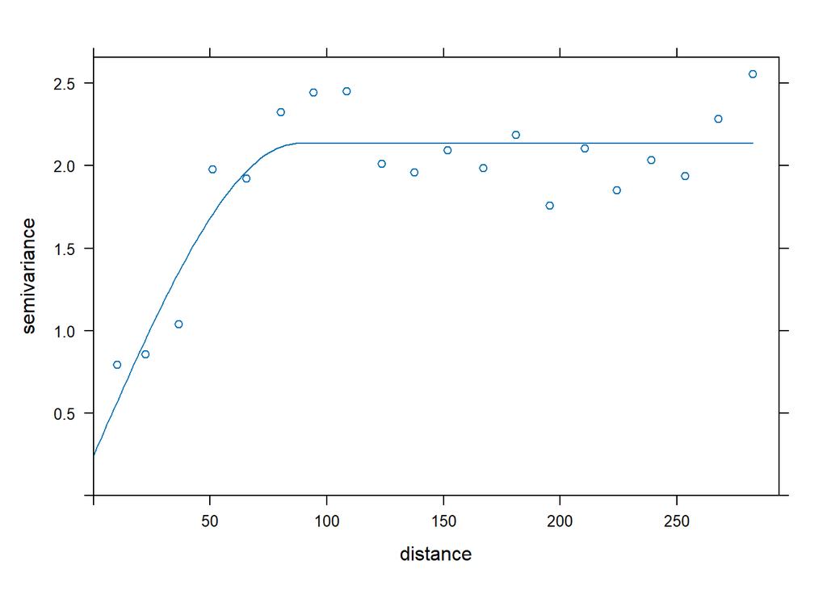

```r
plot(vario, fit_sph)
```

Pintamos los parametros del variograma:

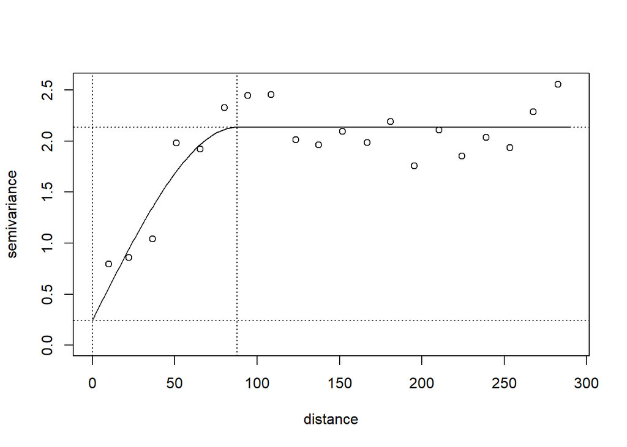

```r
plot(vario$dist, vario$gamma, xlab = "distance", ylab = "semivariance",
     xlim = c(0, max(range_sph*1.1, maxlag)), ylim = c(0, sill_sph*1.2))
lines(variogramLine(fit_sph, maxdist = max(range_sph*1.1, maxlag)))
abline(v = 0, lty = 3)
abline(v = range_sph, lty = 3)
abline(h = nugget_sph, lty = 3)
abline(h = sill_sph, lty = 3)
```

Vamos a comparar los dos modelo a través del valor mínimo de la función objetivo WLS.  
Modelo exponencial:

```r
attr(fit_exp, "SSErr")
```

```
## [1] 193.9797
```

Modelo esférico:

```r
attr(fit_sph, "SSErr")
```

```
## [1] 27.74267
```

Parece que el modelo esférico obtiene un mejor ajuste, a continuación haremos validación cruzada, (mas recomendable).

*c) Emplear medidas de validación cruzada, considerando 10 grupos, para seleccionar el modelo final (establecer la semilla igual al número de grupo multiplicado por 10; no es necesario generar gráficos).*

```r
library(gstat)
set.seed(8*10)# Fijamos una semilla de aleatorización

cv_exp <- krige.cv(formula = temp ~ lon + lat, locations = temp_andalu_sf,
                   model = fit_exp, nfold = 10)

cv_sph <- krige.cv(formula = temp ~ lon + lat, locations = temp_andalu_sf,
                   model = fit_sph, nfold = 10)

summary_cv <- function(cv.data, na.rm = FALSE,
                       tol = sqrt(.Machine$double.eps)) {
  err <- cv.data$residual      # Errores
  obs <- cv.data$observed
  z <- cv.data$zscore
  w <- 1/pmax(cv.data$var1.var, tol) # Ponderación según varianza kriging
  if(na.rm) {
    is.a <- !is.na(err)
    err <- err[is.a]
    obs <- obs[is.a]
    z <- z[is.a]
    w <- w[is.a]
  }
  perr <- 100*err/pmax(obs, tol)  # Errores porcentuales
  return(c(
    # Medidas de error tradicionales
    me = mean(err),           # Error medio
    rmse = sqrt(mean(err^2)), # Raíz del error cuadrático medio
    mae = mean(abs(err)),     # Error absoluto medio
    mpe = mean(perr),         # Error porcentual medio
    mape = mean(abs(perr)),   # Error porcentual absoluto medio
    r.squared = 1 - sum(err^2)/sum((obs - mean(obs))^2), # Pseudo R-cuadrado
    # Medidas de error que tienen en cuenta la varianza kriging
    dme = mean(z),            # Error estandarizado medio
    dmse = sqrt(mean(z^2)),    # Error cuadrático medio adimensional
    rwmse = sqrt(weighted.mean(err^2, w)) # Raíz del ECM ponderado
  ))
}

summary_cv(cv_exp)
```

```
##          me        rmse         mae         mpe        mape   r.squared
## -0.04747616  1.02152710  0.77697360 -2.42818768  9.78312294  0.77676175
##         dme        dmse       rwmse
## -0.04351934  1.37554362  0.89739063
```

```r
summary_cv(cv_sph)
```

```
##          me        rmse         mae         mpe        mape   r.squared
## -0.02641133  1.00576205  0.78340546 -2.15594744  9.86291316  0.78359898
##         dme        dmse       rwmse
## -0.01651296  1.02555044  0.96595693
```

Viendo las medidas calculadas nos podemos fijar en las tres últimas que tienen en cuenta la estimación de la varianza kriging. En estas tres medidas *dme* , *dmse* y *rwmse* el modelo esférico obtiene mejores resultados en 2 de las 3 medidas. *dme* mas cercano a 0, *dmse* mas cercano a 1 pero *rwmse* mas grande. Por ello consideramos que el modelo esférico es mejor modelo.

#### **3. Predicción espacial**

*a. Crear una rejilla de predicción de dimensiones 150x75 que cubra los límites de Anadalucía e intersecarla con dicha región (o una rejilla que cubra las posiciones de observación si surgen dificultades).*

```r
library(stars)
limites <- temp_andalu_sf %>% st_geometry()
```

Grid de 150x75

```r
grid<- limites %>% st_as_stars(nx=150, ny=75)

coord <- st_coordinates(grid)
grid$lon <- coord$x
grid$lat <- coord$y
```

Recortamos la rejilla con los límites de la región de Andalucía (andalucia_limites).

```r
grid <- grid %>% st_crop(andalucia_limites)
```

Grid intersecada con limites de Adalucía

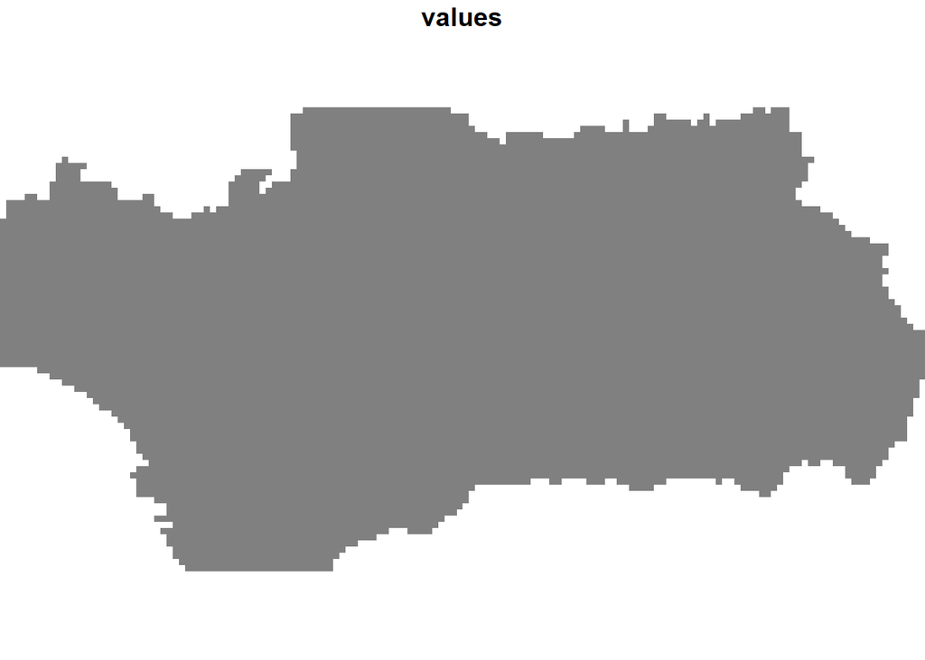

```r
plot(grid)
```

*b. Empleando el modelo obtenido en el ejercicio anterior, calcular las predicciones y varianzas kriging en la rejilla de predicción, y representarlas.*

```r
# Elegimos nuestra función lineal, nuestro sf, el modelo esférico y la rejilla
pred<- krige(formula = temp~lon+lat, locations=temp_andalu_sf, model=fit_sph, newdata=grid)
```

```
## [using universal kriging]
```

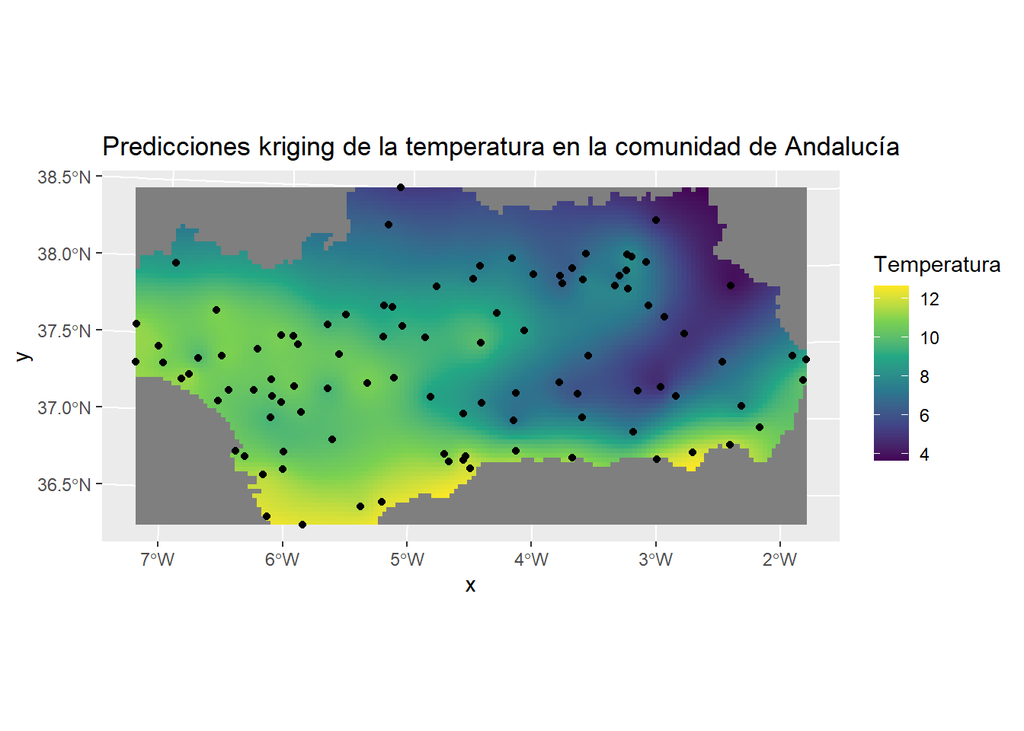

```r
grid$var1.pred <- pred$var1.pred
grid$var1.var <- pred$var1.var

# Utilizamos ggplot para representar:
library(gridExtra)
p1 <- ggplot() + geom_stars(data = grid, aes(fill = var1.pred, x = x, y = y)) +
  scale_fill_viridis_c() + geom_sf(data = temp_andalu_sf) +
  coord_sf(lims_method = "geometry_bbox") +
  labs(title = "Predicciones kriging de la temperatura en la comunidad de Andalucía",
       fill = "Temperatura")

plot(p1)
```

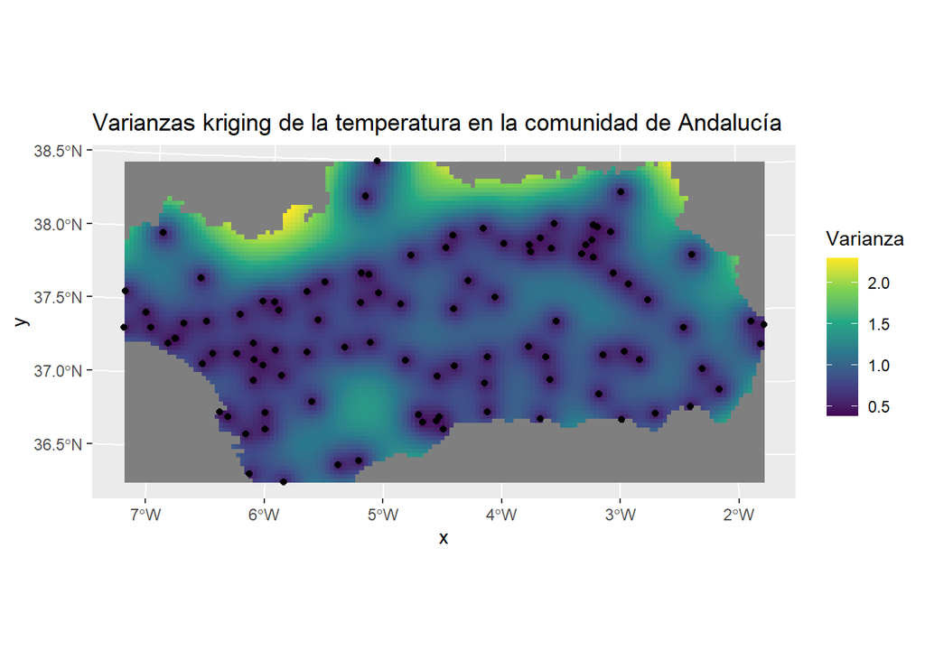

```r
p2 <- ggplot() + geom_stars(data = grid, aes(fill = var1.var, x = x, y = y)) +
  scale_fill_viridis_c() + geom_sf(data = temp_andalu_sf) +
  coord_sf(lims_method = "geometry_bbox") +
  labs(title = "Varianzas kriging de la temperatura en la comunidad de Andalucía",
       fill = "Varianza")

plot(p2)
```